# Datensatzbeschreibung FDZ Gesundheit

Version 0.3.1 | Stand vom 18.03.2026  
Alle Angaben ohne Gewähr. Es können noch Änderungen auftreten.

Die vorliegende Datensatzbeschreibung stellt die Struktur der vom Forschungsdatenzentrum (FDZ) Gesundheit für die Analyse vorgehaltenen Daten dar. Die Datensatzbeschreibung enthält keine Gesundheitsdaten. Der Datensatz ist nicht öffentlich zugänglich, kann aber auf Antrag für Forschungszwecke genutzt werden. Weitere Informationen finden Sie auf unserer [Webseite](https://www.forschungsdatenzentrum-gesundheit.de/).

Die Daten des FDZ Gesundheit werden in einer SAP HANA Datenbank vorgehalten. Sie sind in Form von Tabellen (Satzarten) organisiert. In der Datensatzbeschreibung sind u.a. die Spalten- und Tabellennamen, Datentypen und die Verfügbarkeit nach Berichtsjahren aufgeführt. Die Daten sind in Abhängigkeit der Berichtsjahre auf unterschiedliche Datenmodelle aufgeteilt. Nicht alle Daten sind in allen Datenmodellen und für alle Berichtsjahre verfügbar. Daher haben einige Daten je nach Datenmodell unterschiedliche Spaltennamen (z.B. Berichtsjahr: Datenmodell 1+2 “SAXXX_BERICHTSJAHR”, Datenmodell 3 “BJAHR”).

Die Datenmodelle in den Berichtsjahren:  
Jahre 2009 - 2015: Datenmodell 1  
Jahre 2016 - 2018: Datenmodell 2  
Jahre 2019 - 2023: Datenmodell 3 (enthält deutlich mehr Informationen)

Anschließend finden Sie je Datenmodell ein ER-Diagramm, siehe Entity-Relationship Diagramme (ER-Diagramm Datenmodelle 1 und 2, ER-Diagramm Datenmodell 3).

Außerdem wird eine Übersicht der im FDZ verfügbaren Kataloge gegeben, siehe Abschnitt Kataloge im FDZ.

Das Dokument schließt mit einem vorläufigen Ausblick auf das neue Datenmodell 4 für Daten ab dem Berichtsjahr 2024. Datenmodell 4 stellt eine Erweiterung des Datenmodell 3 mit erneut deutlich mehr Informationen dar. Siehe Abschnitt Geplante Tabellen der FDZ Daten für das kommende Datenmodell 4 (Achtung: vorläufige Informationen, nur Ausblick)“

Weitere Informationen finden Sie darüber hinaus auf unserer [FAQ Seite](https://www.forschungsdatenzentrum-gesundheit.de/infoportal/faqs) und in unserem [GitHub Repository](https://github.com/FDZ-Gesundheit/datensatzbeschreibung_fdz_gesundheit).

Ergänzende Hinweise zu einzelnen Datenfeldern finden Sie auf unserer [Confluence Seite](https://confluence.forschungsdatenzentrum-gesundheit.de/spaces/TTS/pages/130287078/Forschungsdatenzentrum+Home).

**Zitieren:**  
Forschungsdatenzentrum Gesundheit (2025): Datensatzbeschreibung FDZ Gesundheit. Zenodo. [DOI:10.5281/zenodo.11056800](https://doi.org/10.5281/zenodo.11056800).

### Tabellen der FDZ Daten nach Datenmodell

Über den Button “Column visbility” können Sie einzelene Spalten aus- und einblenden.  
Über die Buttons “CSV” und “Excel” können Sie zudem die Tabelle im .csv oder .xlsx Format downloaden.

| Datenmodell | Kategorie | Tabellenname | Beschreibung | Anmerkung | Datenumfang | Verfügbare BJ | BJ 2009 | BJ 2010 | BJ 2011 | BJ 2012 | BJ 2013 | BJ 2014 | BJ 2015 | BJ 2016 | BJ 2017 | BJ 2018 | BJ 2019 | BJ 2020 | BJ 2021 | BJ 2022 | BJ 2023 |
| --- | --- | --- | --- | --- | --- | --- | --- | --- | --- | --- | --- | --- | --- | --- | --- | --- | --- | --- | --- | --- | --- |
| DM1+2 | Versicherte | SA151 | Versichertenstammdaten | Die Basis der Daten ist die Meldung SA110 des BVA. Die Daten stammen aus dem Ausgleichsjahr. | ca. 75 Mio. Zeilen je BJ | 2009, 2010, 2011, 2012, 2013, 2014, 2015, 2016, 2017, 2018 | TRUE | TRUE | TRUE | TRUE | TRUE | TRUE | TRUE | TRUE | TRUE | TRUE | FALSE | FALSE | FALSE | FALSE | FALSE |
| DM1+2 | Versicherte | SA152 | Versichertenstammdaten des Vorjahres des Ausgleichjahres | Die Basis für die Meldung ist die Satzart SA110 des BVA. Die Daten stammen aus dem Vorjahr zum Ausgleichsjahr. | ca. 75 Mio. Zeilen je BJ | 2009, 2010, 2011, 2012, 2013, 2014, 2015, 2016, 2017, 2018 | TRUE | TRUE | TRUE | TRUE | TRUE | TRUE | TRUE | TRUE | TRUE | TRUE | FALSE | FALSE | FALSE | FALSE | FALSE |
| DM1+2 | Versicherte | SA153 | Extrakorporale Blutreinigung | Die Daten der Satzart kennzeichnen Blutwäschen oder Hämodialysen des Vorjahres des Ausgleichsjahres. Die Basis der Daten bildet die Meldung SA100 des BVA. | ca. 75 Mio. Zeilen je BJ | 2009, 2010, 2011, 2012, 2013, 2014, 2015, 2016, 2017, 2018 | TRUE | TRUE | TRUE | TRUE | TRUE | TRUE | TRUE | TRUE | TRUE | TRUE | FALSE | FALSE | FALSE | FALSE | FALSE |
| DM1+2 | Arzneimittel | SA451 | Ambulante Arzneimittel | Die Satzart beinhaltet Daten der ambulanten Arzneimittelverordnungen aus dem Vorjahr des Ausgleichsjahres. | ca. 700 Mio. Zeilen je BJ | 2009, 2010, 2011, 2012, 2013, 2014, 2015, 2016, 2017, 2018 | TRUE | TRUE | TRUE | TRUE | TRUE | TRUE | TRUE | TRUE | TRUE | TRUE | FALSE | FALSE | FALSE | FALSE | FALSE |
| DM1+2 | Voll-/Teilstationäre Fälle | SA551 | Stationäre Diagnosen | Die Daten beinhalten stationäre Diagnosen aus dem Vorjahr des Ausgleichsjahres. | ca. 100 Mio. Zeilen je BJ | 2009, 2010, 2011, 2012, 2013, 2014, 2015, 2016, 2017, 2018 | TRUE | TRUE | TRUE | TRUE | TRUE | TRUE | TRUE | TRUE | TRUE | TRUE | FALSE | FALSE | FALSE | FALSE | FALSE |
| DM1+2 | Ambulante Fälle | SA651 | Ambulante Diagnosen | Die Daten beinhalten ambulante Diagnosen aus dem Vorjahr des Ausgleichsjahres. | ca. 2 Mrd. Zeilen je BJ | 2009, 2010, 2011, 2012, 2013, 2014, 2015, 2016, 2017, 2018 | TRUE | TRUE | TRUE | TRUE | TRUE | TRUE | TRUE | TRUE | TRUE | TRUE | FALSE | FALSE | FALSE | FALSE | FALSE |
| DM1+2 | Leistungsausgaben | SA751 | Leistungsausgaben | Die Satzart beinhaltet personenbezogene berücksichtigungsfähige Leistungsausgaben des Ausgleichsjahres. | ca. 75 Mio. Zeilen je BJ | 2009, 2010, 2011, 2012, 2013, 2014, 2015, 2016, 2017, 2018 | TRUE | TRUE | TRUE | TRUE | TRUE | TRUE | TRUE | TRUE | TRUE | TRUE | FALSE | FALSE | FALSE | FALSE | FALSE |
| DM1+2 | Versicherte | SA951 | Krankenkassenzugehörigkeit | Die Basis der Daten ist die Meldung SA110 des BVA. Die Daten stammen aus dem Ausgleichsjahr. | ca. 75 Mio. Zeilen je BJ | 2009, 2010, 2011, 2012, 2013, 2014, 2015, 2016, 2017, 2018 | TRUE | TRUE | TRUE | TRUE | TRUE | TRUE | TRUE | TRUE | TRUE | TRUE | FALSE | FALSE | FALSE | FALSE | FALSE |
| DM1+2 | Versicherte | SA999 | Amtlicher Gemeindeschlüssel | Die Basis der Daten ist die Meldung SA110 des BVA. Die Daten stammen aus dem Ausgleichsjahr. | ca. 75 Mio. Zeilen je BJ | 2009, 2010 | TRUE | TRUE | FALSE | FALSE | FALSE | FALSE | FALSE | FALSE | FALSE | FALSE | FALSE | FALSE | FALSE | FALSE | FALSE |
| DM1+2 | Versicherte | SA131 | Wohnortangabe nach Postleitzahl | Die Basis der Daten ist die Meldung SA110 des BVA. Die Daten stammen aus dem Ausgleichsjahr. | ca. 75 Mio. Zeilen je BJ | 2016, 2017, 2018 | FALSE | FALSE | FALSE | FALSE | FALSE | FALSE | FALSE | TRUE | TRUE | TRUE | FALSE | FALSE | FALSE | FALSE | FALSE |

[output cut: 17 more lines]

### Datensatzbeschreibung: Felder/Variablen

Hinweis: Die Minimum- und Maximum-Werte stellen lediglich den gültigen Wertebereich dar.

Abkürzungen:

BJ = Berichtsjahr  
DM = Datenmodell

Über den Button “Column visbility” können Sie einzelene Spalten aus- und einblenden.  
Über die Buttons “CSV” und “Excel” können Sie zudem die Tabelle im .csv oder .xlsx Format downloaden.

| Datenmodell | Kategorie | Tabellenname | Datenfeldname | Datenfeldbezeichnung | Beschreibung | Anmerkung | Datentyp | Anzahl Stellen | Min | Max | Ausprägungen | Verfügbare BJ | DM 1 | DM 2 | DM 3 | BJ 2009 | BJ 2010 | BJ 2011 | BJ 2012 | BJ 2013 | BJ 2014 | BJ 2015 | BJ 2016 | BJ 2017 | BJ 2018 | BJ 2019 | BJ 2020 | BJ 2021 | BJ 2022 | … |
| --- | --- | --- | --- | --- | --- | --- | --- | --- | --- | --- | --- | --- | --- | --- | --- | --- | --- | --- | --- | --- | --- | --- | --- | --- | --- | --- | --- | --- | --- | --- |
| DM1+2 | Versicherte | SA151 | SA151_SATZART | Satzart | Konstanter Wert. |  | SMALLINT | 3 |  |  | 151 | 2009, 2010, 2011, 2012, 2013, 2014, 2015, 2016, 2017, 2018 | TRUE | TRUE | FALSE | TRUE | TRUE | TRUE | TRUE | TRUE | TRUE | TRUE | TRUE | TRUE | TRUE | FALSE | FALSE | FALSE | FALSE | … |
| DM1+2 | Versicherte | SA151 | SA151_AUSGLEICHSJAHR | Ausgleichsjahr | JJJJ Jahr, für das der Morbi-RSA berechnet wird |  | SMALLINT | 4 | 1900 | 2500 |  | 2009, 2010, 2011, 2012, 2013, 2014, 2015, 2016, 2017, 2018 | TRUE | TRUE | FALSE | TRUE | TRUE | TRUE | TRUE | TRUE | TRUE | TRUE | TRUE | TRUE | TRUE | FALSE | FALSE | FALSE | FALSE | … |
| DM1+2 | Versicherte | SA151 | SA151_BERICHTSJAHR | Berichtsjahr | JJJJ Jahr, in dem die Daten erhoben wurden | Das Berichtsjahr aus dieser Spalte ist maßgeblich für das im Antrag ausgewählte Jahr bei dieser Satzart. | SMALLINT | 4 | 1900 | 2500 |  | 2009, 2010, 2011, 2012, 2013, 2014, 2015, 2016, 2017, 2018 | TRUE | TRUE | FALSE | TRUE | TRUE | TRUE | TRUE | TRUE | TRUE | TRUE | TRUE | TRUE | TRUE | FALSE | FALSE | FALSE | FALSE | … |
| DM1+2 | Versicherte | SA151 | SA151_VSID | Einjähriges Pseudonym | Versicherten-ID zum Ausgleichjahr bzw. Berichtjahr (Pseudonym). Dient zur Verknüpfung zwischen Tabellen innerhalb eines Berichtsjahres. | Im Allgemeinen hat eine natürliche Person (PSID) innerhalb eines Berichtsjahres nur eine VSID. Mehrere VSID existieren nur, wenn diese Person innerhalb des Jahres die Versicherung gewechselt hat. | VARCHAR(32) | 32 |  |  |  | 2009, 2010, 2011, 2012, 2013, 2014, 2015, 2016, 2017, 2018 | TRUE | TRUE | FALSE | TRUE | TRUE | TRUE | TRUE | TRUE | TRUE | TRUE | TRUE | TRUE | TRUE | FALSE | FALSE | FALSE | FALSE | … |
| DM1+2 | Versicherte | SA151 | SA151_PSID | Überjähriges Pseudonym | Überjährige Versicherten-ID (Pseudonym) zur Verknüpfung gleicher Personen zwischen Tabellen (ein- und überjährig). | Im Allgemeinen hat eine natürliche Person (PSID) innerhalb eines Berichtsjahres nur eine VSID. Mehrere VSID existieren nur, wenn diese Person innerhalb des Jahres die Versicherung gewechselt hat. | VARCHAR(32) | 32 |  |  |  | 2009, 2010, 2011, 2012, 2013, 2014, 2015, 2016, 2017, 2018 | TRUE | TRUE | FALSE | TRUE | TRUE | TRUE | TRUE | TRUE | TRUE | TRUE | TRUE | TRUE | TRUE | FALSE | FALSE | FALSE | FALSE | … |
| DM1+2 | Versicherte | SA151 | SA151_KV_NR_KENNZEICHEN | Krankenversicherungsnummer (KV) | bundeseinheitliche KV Nummer lag vor= 1 \| sonst = 0 |  | TINYINT | 1 |  |  | bundeseinheitliche KV-Nr lag vor = 1; sonst = 0 | 2009, 2010, 2011, 2012, 2013, 2014, 2015, 2016, 2017, 2018 | TRUE | TRUE | FALSE | TRUE | TRUE | TRUE | TRUE | TRUE | TRUE | TRUE | TRUE | TRUE | TRUE | FALSE | FALSE | FALSE | FALSE | … |
| DM1+2 | Versicherte | SA151 | SA151_GEBURTSJAHR | Geburtsjahr | Geburtsjahr des Versicherten JJJJ |  | SMALLINT | 4 | 1800 | 2500 |  | 2009, 2010, 2011, 2012, 2013, 2014, 2015, 2016, 2017, 2018 | TRUE | TRUE | FALSE | TRUE | TRUE | TRUE | TRUE | TRUE | TRUE | TRUE | TRUE | TRUE | TRUE | FALSE | FALSE | FALSE | FALSE | … |
| DM1+2 | Versicherte | SA151 | SA151_GESCHLECHT | Geschlecht |  |  | TINYINT | 1 | 1 | 4 | 1 = weiblich; 2 = männlich; 3 = fehlende Geschlechtsangabe gemäß § 30 Abs. 1 Satz Nr. 1 RSAV (ab BJ2016); 4 = divers (ab BJ2018) | 2009, 2010, 2011, 2012, 2013, 2014, 2015, 2016, 2017, 2018 | TRUE | TRUE | FALSE | TRUE | TRUE | TRUE | TRUE | TRUE | TRUE | TRUE | TRUE | TRUE | TRUE | FALSE | FALSE | FALSE | FALSE | … |
| DM1+2 | Versicherte | SA151 | SA151_VERSICHERTENTAGE | Versichertentage | Versichertentage des Versicherten im Berichtsjahr gemäß § 30 Abs. 1 Nr. 1 RSAV |  | SMALLINT | 3 | 0 | 400 |  | 2009, 2010, 2011, 2012, 2013, 2014, 2015, 2016, 2017, 2018 | TRUE | TRUE | FALSE | TRUE | TRUE | TRUE | TRUE | TRUE | TRUE | TRUE | TRUE | TRUE | TRUE | FALSE | FALSE | FALSE | FALSE | … |
| DM1+2 | Versicherte | SA151 | SA151_VERSTORBEN | Vitalstatus | Versicherter ist im Berichtsjahr verstorben 0 = sonst |  | TINYINT | 1 | 0 | 1 | 0 = in diesem Jahr nicht verstorben; 1 = in diesem Jahr verstorben | 2009, 2010, 2011, 2012, 2013, 2014, 2015, 2016, 2017, 2018 | TRUE | TRUE | FALSE | TRUE | TRUE | TRUE | TRUE | TRUE | TRUE | TRUE | TRUE | TRUE | TRUE | FALSE | FALSE | FALSE | FALSE | … |

[output cut: 306 more lines]

### Entity-Relationship Diagramme

#### ER-Diagramm Datenmodelle 1 und 2

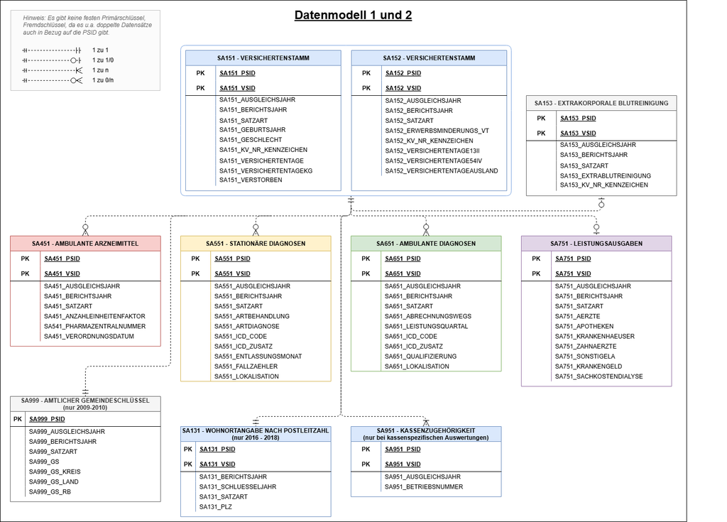

#### ER-Diagramm Datenmodell 3

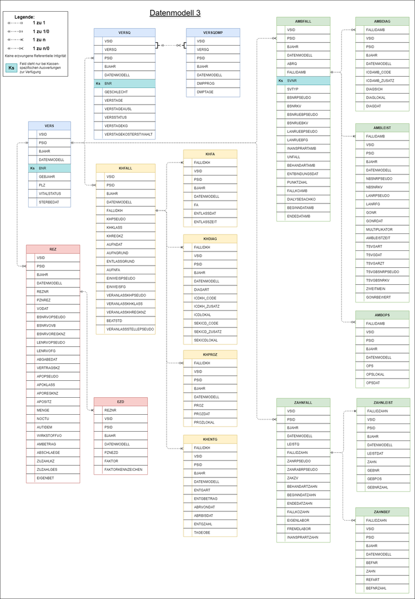

### Geplante Tabellen der FDZ Daten für das kommende Datenmodell 4 (Achtung: vorläufige Informationen, nur Ausblick)

Über den Button “Column visbility” können Sie einzelene Spalten aus- und einblenden.  
Über die Buttons “CSV” und “Excel” können Sie zudem die Tabelle im .csv oder .xlsx Format downloaden.

| Datenmodell | Kategorie | Tabellenname | Beschreibung | Anmerkung | Datenumfang | Verfügbare BJ | BJ 2019 | BJ 2020 | BJ 2021 | BJ 2022 | BJ 2023 | BJ 2024 |
| --- | --- | --- | --- | --- | --- | --- | --- | --- | --- | --- | --- | --- |
| DM4 | Versicherte | VERS | Angaben zur oder zum Versicherten |  | ca. 300 Mio. Zeilen je BJ | 2019, 2020, 2021, 2022, 2023, 2024 | TRUE | TRUE | TRUE | TRUE | TRUE | TRUE |
| DM4 | Versicherte | VERSDMP | Angaben zur oder zum Versicherten |  | ca. 32 Mio. Zeilen je BJ | 2019, 2020, 2021, 2022, 2023, 2024 | TRUE | TRUE | TRUE | TRUE | TRUE | TRUE |
| DM4 | Ambulante Fälle | AMBFALL | Fälle der kollektiv- und selektivvertraglichen Versorgung durch niedergelassene Vertragsärztinnen und -ärzte |  | ca. 630 Mio. Zeilen je BJ | 2019, 2020, 2021, 2022, 2023, 2024 | TRUE | TRUE | TRUE | TRUE | TRUE | TRUE |
| DM4 | Ambulante Fälle | AMBDIAG | Diagnosen der kollektiv- oder selektivvertraglichen Versorgung |  | ca. 3 Mrd. Zeilen je BJ | 2019, 2020, 2021, 2022, 2023, 2024 | TRUE | TRUE | TRUE | TRUE | TRUE | TRUE |
| DM4 | Ambulante Fälle | AMBLEIST | Leistungen der kollektiv- oder selektivvertraglichen Versorgung |  | ca. 5 Mrd. Zeilen je BJ | 2019, 2020, 2021, 2022, 2023, 2024 | TRUE | TRUE | TRUE | TRUE | TRUE | TRUE |
| DM4 | Ambulante Fälle | AMBOPS | Operationen und Prozeduren der kollektiv- oder selektivvertraglichen Versorgung |  | ca. 14 Mio. Zeilen je BJ | 2019, 2020, 2021, 2022, 2023, 2024 | TRUE | TRUE | TRUE | TRUE | TRUE | TRUE |
| DM4 | Ambulante Fälle | AMBFALLV | Fälle der kollektivvertraglichen Versorgung durch Vertragsärztinnen und -ärzte (Vorab-Daten nach § 295b SGB V) |  | ??? | 2024 | FALSE | FALSE | FALSE | FALSE | FALSE | TRUE |
| DM4 | Ambulante Fälle | AMBDIAGV | Diagnosen der kollektivvertraglichen Versorgung (Vorab-Daten nach § 295b SGB V) |  | ??? | 2024 | FALSE | FALSE | FALSE | FALSE | FALSE | TRUE |
| DM4 | Ambulante Fälle | AMBLEISTV | Leistungen der kollektivvertraglichen Versorgung (Vorab-Daten nach § 295b SGB V) |  | ??? | 2024 | FALSE | FALSE | FALSE | FALSE | FALSE | TRUE |
| DM4 | Ambulante Fälle | AMBOPSV | Operationen und Prozeduren der kollektivvertraglichen Versorgung (Vorab-Daten nach § 295b SGB V) |  | ??? | 2024 | FALSE | FALSE | FALSE | FALSE | FALSE | TRUE |

[output cut: 52 more lines]

### Datensatzbeschreibung: Felder/Variablen für das kommende Datenmodell 4 (Achtung: vorläufige Informationen, nur Ausblick)

Die folgende Übersicht soll Antragstellenden eine erste Orientierung über potenziell verfügbare Felder im Datenmodell DM4 geben und einen vorläufigen Eindruck der zukünftigen Datenstruktur vermitteln.

Bitte beachten Sie, dass es sich hierbei ausschließlich um vorläufige Informationen handelt. Daten aus DM4 können zum jetzigen Zeitpunkt noch nicht beantragt werden. Datentypen sowie mögliche Einschränkungen – beispielsweise im Hinblick auf kassenspezifische Anträge – sind derzeit noch nicht abschließend geprüft. Änderungen sind daher jederzeit möglich.

Der Fokus dieser Übersicht liegt ausschließlich auf den für Forschungsfragen relevanten Nutzdaten, also den von den Krankenkassen gelieferten Abrechnungsdaten. Tabellen-Spalten bzw. Felder, die ausschließlich der internen technischen Verwaltung dienen (z. B. zur Verknüpfung von Tabellen), sind daher entweder nicht enthalten oder nur angedeutet. So wird beispielsweise das Feld ARBNR in dieser Darstellung in die beiden Felder VSID und PSID aufgeteilt.

Die Darstellung stellt keine vollständige Beschreibung der zukünftigen Tabellenstruktur dar. Sie dient lediglich als vorläufiger Ausblick auf mögliche Felder und kann daher nicht unmittelbar mit der oben dargestellten Feldliste der bereits im FDZ verfügbaren Variablen verglichen werden

Hinweis: Die Minimum- und Maximum-Werte stellen lediglich den gültigen Wertebereich dar.

Abkürzungen:

BJ = Berichtsjahr  
DM = Datenmodell

Über den Button “Column visbility” können Sie einzelene Spalten aus- und einblenden.  
Über die Buttons “CSV” und “Excel” können Sie zudem die Tabelle im .csv oder .xlsx Format downloaden.

| Datenmodell | Kategorie | Tabellenname | Datenfeldname | Datenfeldbezeichnung | Beschreibung | Anmerkung | Datentyp | Anzahl Stellen | Min | Max | Ausprägungen | Verfügbare BJ | DM 3 | DM 4 | BJ 2019 | BJ 2020 | BJ 2021 | BJ 2022 | BJ 2023 | BJ 2024 |
| --- | --- | --- | --- | --- | --- | --- | --- | --- | --- | --- | --- | --- | --- | --- | --- | --- | --- | --- | --- | --- |
| DM4 | Versicherte | VERS | ARBNR (bzw: VSID & PSID) | Arbeitsnummer der oder des Versicherten | Gemäß § 4 Abs. 4 von der Datensammelstelle zum periodenbezogenen Lieferpseudonym erzeugt | Durch Datensammmelstelle erzeugt | numerisch | 9 |  |  |  | 2019, 2020, 2021, 2022, 2023, 2024 | FALSE | TRUE | TRUE | TRUE | TRUE | TRUE | TRUE | TRUE |
| DM4 | Versicherte | VERS | GEBJAHR | Geburtsjahr | Format JJJJ | Durch datenliefernde Stelle erzeugt | numerisch | 4 | 1800 | 2500 |  | 2019, 2020, 2021, 2022, 2023, 2024 | FALSE | TRUE | TRUE | TRUE | TRUE | TRUE | TRUE | TRUE |
| DM4 | Versicherte | VERS | PLZ | Postleitzahl | Postleitzahl des Wohnorts der oder des Versicherten; "00000" für Wohnausländer; es wird die aktuell verfügbare Postleitzahl zum Zeitpunkt des Datenabzugs gemeldet; siehe auch Hinweis im Tabellenblatt … | Durch datenliefernde Stelle erzeugt | alphanum. | 5 |  |  | "00000" für Wohnausländer | 2019, 2020, 2021, 2022, 2023, 2024 | FALSE | TRUE | TRUE | TRUE | TRUE | TRUE | TRUE | TRUE |
| DM4 | Versicherte | VERS | AGS | Amtlicher Gemeindeschlüssel | Amtlicher Gemeindeschlüssel des Wohnortes der oder des Versicherten; "00000000" = Ausland; "99999999" = nicht zugeordnet; es wird der aktuell verfügbare amtliche Gemeindeschlüssel zum Zeitpunkt des Da… | Durch datenliefernde Stelle erzeugt | numerisch | 8 |  |  |  | 2019, 2020, 2021, 2022, 2023, 2024 | FALSE | TRUE | TRUE | TRUE | TRUE | TRUE | TRUE | TRUE |
| DM4 | Versicherte | VERS | VITALSTATUS | Vitalstatus | 0 = Nicht verstorben 1 = Verstorben Es wird der aktuell verfügbare Status zum Zeitpunkt des Datenabzugs gemeldet. | Durch datenliefernde Stelle erzeugt | numerisch | 1 | 0 | 1 | 0 = in diesem Jahr nicht verstorben; 1 = in diesem Jahr verstorben | 2019, 2020, 2021, 2022, 2023, 2024 | FALSE | TRUE | TRUE | TRUE | TRUE | TRUE | TRUE | TRUE |
| DM4 | Versicherte | VERS | STERBEDAT | Datum des Sterbetages | Datum des Sterbetages im Format JJJJMMTT; es wird das aktuell verfügbare Datum zum Zeitpunkt des Datenabzugs gemeldet. | Durch datenliefernde Stelle erzeugt | numerisch | 8 |  |  |  | 2019, 2020, 2021, 2022, 2023, 2024 | FALSE | TRUE | TRUE | TRUE | TRUE | TRUE | TRUE | TRUE |
| DM4 | Versicherte | VERS | GESCHLECHT | Geschlecht | 1 = Weiblich 2 = Männlich 3 = Fehlende Geschlechtsangabe 4 = Divers Es wird die aktuell verfügbare Geschlechtsangabe zum Zeitpunkt des Datenabzugs gemeldet. | Durch datenliefernde Stelle erzeugt | numerisch | 1 |  |  |  | 2019, 2020, 2021, 2022, 2023, 2024 | FALSE | TRUE | TRUE | TRUE | TRUE | TRUE | TRUE | TRUE |
| DM4 | Versicherte | VERS | VERSTAGE | Anzahl Versichertentage | Anzahl Versichertentage im Berichtsquartal | Durch datenliefernde Stelle erzeugt | numerisch | 1..2 |  |  |  | 2019, 2020, 2021, 2022, 2023, 2024 | FALSE | TRUE | TRUE | TRUE | TRUE | TRUE | TRUE | TRUE |
| DM4 | Versicherte | VERS | VERSTAGEAUSL | Anzahl Versichertentage mit Wohnsitz im Ausland | Anzahl Versichertentage im Berichtsquartal mit Wohnsitz im Ausland im Berichtsquartal | Durch datenliefernde Stelle erzeugt | numerisch | 1..2 |  |  |  | 2019, 2020, 2021, 2022, 2023, 2024 | FALSE | TRUE | TRUE | TRUE | TRUE | TRUE | TRUE | TRUE |
| DM4 | Versicherte | VERS | VERSSTATUS | Versichertenstatus gemäß KM 1 | Versichertenstatus gemäß KM 1 des Berichtsquartals; wenn technisch kein KM 1-Versichertenstatus für das Berichtsquartal ermittelt werden kann,"99999" Bei Veränderungen innerhalb des Berichtsquartals d… | Durch datenliefernde Stelle erzeugt | numerisch | 5 |  |  |  | 2019, 2020, 2021, 2022, 2023, 2024 | FALSE | TRUE | TRUE | TRUE | TRUE | TRUE | TRUE | TRUE |

[output cut: 625 more lines]

[Impressum](https://www.bfarm.de/DE/Service/Impressum/_node.html)